# Regression and model validation

*We have preprocessed a data set for further analysis and have performed and interpreted regression analysis. The following includes the codes and my explanations and interpretations for the analysis part.*

```r
lrn2014 <- read.table("data/lrn2014.txt", header = TRUE)

str(lrn2014)
```

```
## 'data.frame':    166 obs. of  7 variables:
##  $ Age     : int  53 55 49 53 49 38 50 37 37 42 ...
##  $ Attitude: int  37 31 25 35 37 38 35 29 38 21 ...
##  $ Points  : int  25 12 24 10 22 21 21 31 24 26 ...
##  $ gender  : Factor w/ 2 levels "F","M": 1 2 1 2 2 1 2 1 2 1 ...
##  $ deep    : num  3.58 2.92 3.5 3.5 3.67 ...
##  $ surf    : num  2.58 3.17 2.25 2.25 2.83 ...
##  $ stra    : num  3.38 2.75 3.62 3.12 3.62 ...
```

```r
dim(lrn2014)
```

```
## [1] 166   7
```

lrn2014 is a data set with data from 166 students in 7 variables: age, attitude, points, gender, variable related to deep learning, variable related to surface learning and a variable related to strategic learning.

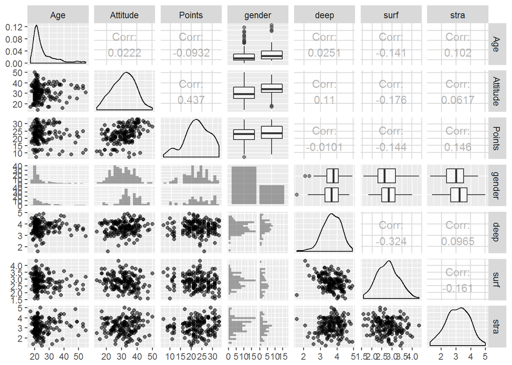

```r
library(GGally)
library(ggplot2)

ggpairs(lrn2014, mapping = aes(alpha = 0.3), lower = list(combo = wrap("facethist", bins = 20)))
```

```r
summary(lrn2014)
```

```
##       Age           Attitude         Points      gender       deep
##  Min.   :17.00   Min.   :14.00   Min.   : 7.00   F:110   Min.   :1.583
##  1st Qu.:21.00   1st Qu.:26.00   1st Qu.:19.00   M: 56   1st Qu.:3.333
##  Median :22.00   Median :32.00   Median :23.00           Median :3.667
##  Mean   :25.51   Mean   :31.43   Mean   :22.72           Mean   :3.680
##  3rd Qu.:27.00   3rd Qu.:37.00   3rd Qu.:27.75           3rd Qu.:4.083
##  Max.   :55.00   Max.   :50.00   Max.   :33.00           Max.   :4.917
##       surf            stra
##  Min.   :1.583   Min.   :1.250
##  1st Qu.:2.417   1st Qu.:2.625
##  Median :2.833   Median :3.188
##  Mean   :2.787   Mean   :3.121
##  3rd Qu.:3.167   3rd Qu.:3.625
##  Max.   :4.333   Max.   :5.000
```

- age: the median age is 22, the major part of participants are of around this age with few acceptions in higher age groups
- attitude: follows a normal distribution. Shows highest correlation with the variable points.
- points: shows a left-tailed skweded distribution
- gender: almost twice as many females than males (110 vs 56), no obvious relationship with other parameters.
- deep: slightly left-tailed skewed distribution. Negative correlation with surface learning.
- surf: slightly right-tailed skewed distribution. Slight negative correlation with attitude and points.
- stra: normally distributed. Slight positive correlation with points.

```r
lm.lrn2014.1 <- lm(Points ~ Attitude + surf + stra , data = lrn2014)
summary(lm.lrn2014.1)
```

```
##
## Call:
## lm(formula = Points ~ Attitude + surf + stra, data = lrn2014)
##
## Residuals:
##      Min       1Q   Median       3Q      Max
## -17.1550  -3.4346   0.5156   3.6401  10.8952
##
## Coefficients:
##             Estimate Std. Error t value Pr(>|t|)
## (Intercept) 11.01711    3.68375   2.991  0.00322 **
## Attitude     0.33952    0.05741   5.913 1.93e-08 ***
## surf        -0.58607    0.80138  -0.731  0.46563
## stra         0.85313    0.54159   1.575  0.11716
## ---
## Signif. codes:  0 '***' 0.001 '**' 0.01 '*' 0.05 '.' 0.1 ' ' 1
##
## Residual standard error: 5.296 on 162 degrees of freedom
## Multiple R-squared:  0.2074, Adjusted R-squared:  0.1927
## F-statistic: 14.13 on 3 and 162 DF,  p-value: 3.156e-08
```

in lm.lrn2014.1, surf and stra do not have a statistically significant relationship with points (alpha = 0.05)

```r
lm.lrn2014.2 <- lm(Points ~ Attitude + stra, data = lrn2014)
summary(lm.lrn2014.2)
```

```
##
## Call:
## lm(formula = Points ~ Attitude + stra, data = lrn2014)
##
## Residuals:
##      Min       1Q   Median       3Q      Max
## -17.6436  -3.3113   0.5575   3.7928  10.9295
##
## Coefficients:
##             Estimate Std. Error t value Pr(>|t|)
## (Intercept)  8.97290    2.39591   3.745  0.00025 ***
## Attitude     0.34658    0.05652   6.132 6.31e-09 ***
## stra         0.91365    0.53447   1.709  0.08927 .
## ---
## Signif. codes:  0 '***' 0.001 '**' 0.01 '*' 0.05 '.' 0.1 ' ' 1
##
## Residual standard error: 5.289 on 163 degrees of freedom
## Multiple R-squared:  0.2048, Adjusted R-squared:  0.1951
## F-statistic: 20.99 on 2 and 163 DF,  p-value: 7.734e-09
```

in lm.lrn2014.2, stra does not have a statistically significant relationship with points (alpha = 0.05)

```r
lm.lrn2014.3 <- lm(Points ~ Attitude, data = lrn2014)
summary(lm.lrn2014.3)
```

```
##
## Call:
## lm(formula = Points ~ Attitude, data = lrn2014)
##
## Residuals:
##      Min       1Q   Median       3Q      Max
## -16.9763  -3.2119   0.4339   4.1534  10.6645
##
## Coefficients:
##             Estimate Std. Error t value Pr(>|t|)
## (Intercept) 11.63715    1.83035   6.358 1.95e-09 ***
## Attitude     0.35255    0.05674   6.214 4.12e-09 ***
## ---
## Signif. codes:  0 '***' 0.001 '**' 0.01 '*' 0.05 '.' 0.1 ' ' 1
##
## Residual standard error: 5.32 on 164 degrees of freedom
## Multiple R-squared:  0.1906, Adjusted R-squared:  0.1856
## F-statistic: 38.61 on 1 and 164 DF,  p-value: 4.119e-09
```

in lm.lrn2014.3, attitude has a statistically significant relationship with points (alpha = 0.05)

- The model shows that the target variable points is expected to increase 0.35 when the attitude increases by 1. The t value and P value correspond to the statistical test with the null hypothesis that the parameter would be 0.
- The multiple R-squared is the fraction of the target variable points that is explained by the model. In this csae, 19% of the variation in points is explained by the model.

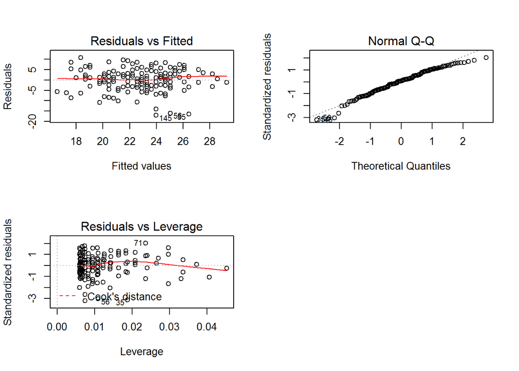

```r
par(mfrow = c(2,2))
plot(lm.lrn2014.3, which = c(1,2,5))
```

The model obviously assumes linearity, but also a normal distribution of the errors, that the errors are not correlated and have a constant variance. The latter means that the size of the error does not depend on the explanatory variables.

- residuals vs Fitted: Any pattern in the residuals vs fitted plot would indicate a problem with the assumption of constant error and independence of explanatory variables. For our model, this plot shows a cloud of randomly distributed points, indicating that this assumption is met.
- Q-Q qplot: the better the data point fit with the line, the better the normality assumption is met. In our model, there is a reasonable fit with the line.
- Residuals vs Levarage: this plot helps to identify data points with unusually high impact. Our data does not show single points with high leverage.